# The Power of names()

by Kolapo Obajuluwa

## Hi! What’s your name?

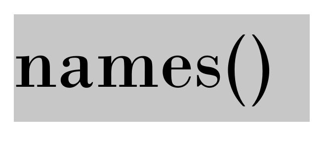

names()

The names function in R is a simple yet powerful function for accessing and even replacing “names” of attributes of vectors and objects.

To illustrate this, we’ll be working with some air quality data from kaggle, it covers air quality in India from 2015 to 2020. Here’s a link to the [dataset](https://www.kaggle.com/rohanrao/air-quality-data-in-india).

You can get the code for this on [my github](https://github.com/kolaoba/R_AirQualityScripts/)

Downloaded the data? Let’s load it.

```r
wkdir <- "C:/Users/koli0/Downloads/Compressed/archive/"

csvs <- list.files(path = wkdir, pattern = "*.csv")

csvs
```

```
[1] "city_day.csv"     "city_hour.csv"    "station_day.csv"  "station_hour.csv"
[5] "stations.csv"
```

We want granular data, at least time-wise, so let’s go with the hourly data. We’re not focusing on spatial variation right now so we’ll load the data by city (city_hour.csv) and have a quick glance at it.

```r
testr1 <- read.csv(paste(wkdir,csvs[2],sep =""))
head(testr1)
```

|  | City | Datetime | PM2.5 | PM10 | NO | NO2 | NOx | NH3 | CO | SO2 | O3 | Benzene | Toluene | Xylene | AQI | AQI_Bucket |
| --- | --- | --- | --- | --- | --- | --- | --- | --- | --- | --- | --- | --- | --- | --- | --- | --- |
| 1 | Ahmedabad | 2015-01-01 01:00:00 | NA | NA | 1.00 | 40.01 | 36.37 | NA | 1.00 | 122.07 | NA | 0 | 0 | 0 | NA |  |
| 2 | Ahmedabad | 2015-01-01 02:00:00 | NA | NA | 0.02 | 27.75 | 19.73 | NA | 0.02 | 85.90 | NA | 0 | 0 | 0 | NA |  |
| 3 | Ahmedabad | 2015-01-01 03:00:00 | NA | NA | 0.08 | 19.32 | 11.08 | NA | 0.08 | 52.83 | NA | 0 | 0 | 0 | NA |  |
| 4 | Ahmedabad | 2015-01-01 04:00:00 | NA | NA | 0.30 | 16.45 | 9.20 | NA | 0.30 | 39.53 | 153.58 | 0 | 0 | 0 | NA |  |
| 5 | Ahmedabad | 2015-01-01 05:00:00 | NA | NA | 0.12 | 14.90 | 7.85 | NA | 0.12 | 32.63 | NA | 0 | 0 | 0 | NA |  |
| 6 | Ahmedabad | 2015-01-01 06:00:00 | NA | NA | 0.33 | 15.95 | 10.82 | NA | 0.33 | 29.87 | 64.25 | 0 | 0 | 0 | NA |  |

Now we’ll take a look at the unique cities as we do not need ALL the data for this.

```r
unique(testr1$City)
```

```
 [1] "Ahmedabad"          "Aizawl"             "Amaravati"          "Amritsar"
 [5] "Bengaluru"          "Bhopal"             "Brajrajnagar"       "Chandigarh"
 [9] "Chennai"            "Coimbatore"         "Delhi"              "Ernakulam"
[13] "Gurugram"           "Guwahati"           "Hyderabad"          "Jaipur"
[17] "Jorapokhar"         "Kochi"              "Kolkata"            "Lucknow"
[21] "Mumbai"             "Patna"              "Shillong"           "Talcher"
[25] "Thiruvananthapuram" "Visakhapatnam"
```

Let’s filter the data to cover just Mumbai. We’ll need the “dplyr” package for this.

```r
library(dplyr)
```

```r
mumbai_aq <- filter(testr1, City == "Mumbai" )
```

Let’s get a list of its headers using the names function

```r
names(mumbai_aq)
```

```
 [1] "City"       "Datetime"   "PM2.5"      "PM10"       "NO"         "NO2"        "NOx"
 [8] "NH3"        "CO"         "SO2"        "O3"         "Benzene"    "Toluene"    "Xylene"
[15] "AQI"        "AQI_Bucket"
```

This is pretty basic use of names; getting the headers in a dataframe. This simple feature can unlock so much more. Let’s go!

To get these plots, we’ll be using an awesome package from David Carslaw called “openair”. It’s a neat package for air quality analysis. You can install using install.packages(“openair”) or you can get it directly from his [github](https://davidcarslaw.github.io/openair/). I’ll load it below since i have it installed already.

```r
library(openair)
```

To properly analyse time-series data using the openair package, we need to establish a date column of the POSIXct type. So we do this from our DateTime column as it’s currently a character column

```r
mumbai_aq$date <- as.POSIXct(mumbai_aq$Datetime, tz = "GMT", "%Y-%m-%d %H:%M:%S")
class(mumbai_aq$date)
```

```
[1] "POSIXct" "POSIXt"
```

For the diurnal plots, we’ll be using the timeVariation function in the openair package. It plots the diurnal, day of the week and monthly variation plots for different pollutants.

Let’s plot for Nox

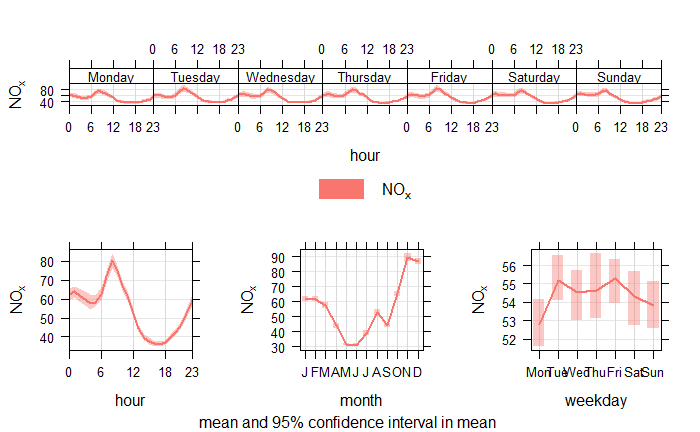

```r
nox_plt <- timeVariation(mumbai_aq, pollutant = 'NOx')
```

Let’s check the variable

```
openair object created by:
    timeVariation(mydata = mumbai_aq, pollutant = "NOx")

this contains:
    4 data frame(s):
    $data$day.hour, $data$hour, $data$day, $data$month
    4 plot objects(s):
    $plot$day.hour, $plot$hour, $plot$day, $plot$month
```

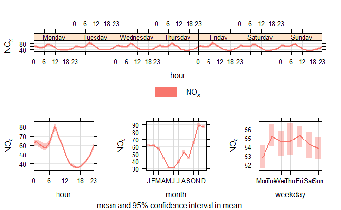

```r
nox_plt
```

Okay. Our diurnal plot is in the bottom left, “sitting pretty”. We want this plot to stand alone as we aim to compare with similar plots for two other pollutants. [Documentation](https://davidcarslaw.github.io/openair/reference/timeVariation.html) for the openair package shows us how to obtain individual plots using the subset function, let’s try it out.

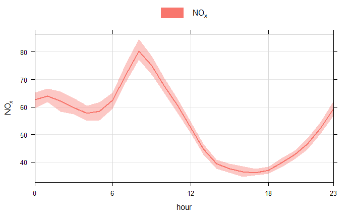

```r
plot(nox_plt, subset = "hour")
```

Awesome! Now let’s assign this plot to a variable.

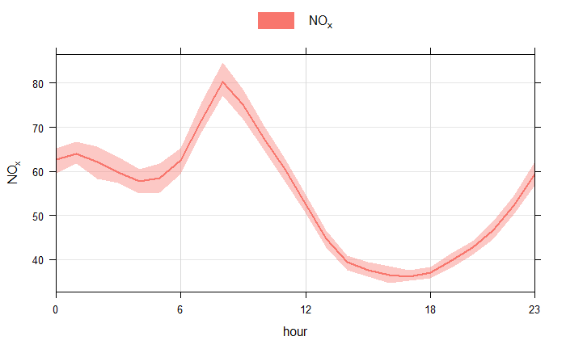

```r
nox_plt_hr <- plot(nox_plt, subset = "hour")
```

Checking the variable

```r
nox_plt_hr
```

Uh-oh! It doesn’t appear to store the plot to a variable.

In situations like this, we may want to look deeper into our variables to see what they actually are. This is where the power of “names” shines. Let’s start from the timeVariation plot.

```r
names(nox_plt)
```

```
[1] "plot" "data" "call"
```

The timeVariation plot is an openair object which contains three items. Object items can be referenced easily in R with [[]]. So let’s look further into the plot item.

```r
names(nox_plt[["plot"]])
```

```
[1] "day.hour" "hour"     "day"      "month"    "subsets"
```

Aha! We seem to have found the items that constituted the initial timeVariation plot. Our plot of interest is the diurnal plot titled “hour”.

Let’s try to store the plot to a variable using this referencing

```r
nox_plt_hr <- nox_plt[["plot"]][["hour"]]
```

Quick check to see if it’s stored.

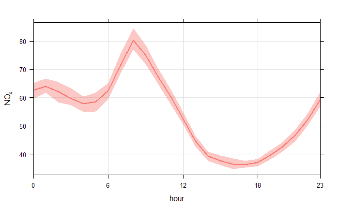

```r
nox_plt_hr
```

Awesome! so our plot is stored and we can replicate this for our other pollutants.

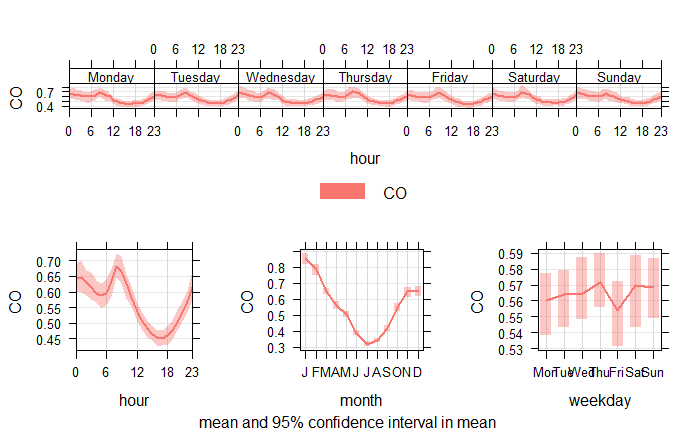

```r
co_plt <- timeVariation(mumbai_aq, pollutant = 'CO')
```

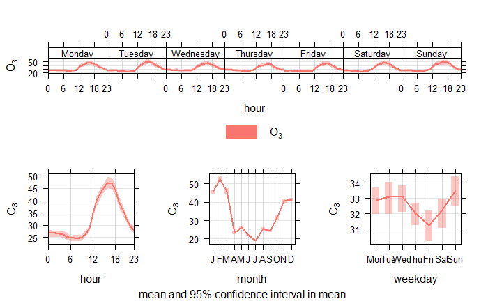

```r
co_plt_hr <- co_plt[["plot"]][["hour"]]

o3_plt <- timeVariation(mumbai_aq, pollutant = 'O3')
```

```r
o3_plt_hr <- o3_plt[["plot"]][["hour"]]
```

## Editing the Plot Components

These plots are generated for us by the timeVariation function and as such, we may not be able to edit its components (labels, axes, limits etc), Or can we?!

Let’s see if we are able to reference the plot object any further using the names function.

```r
names(nox_plt_hr)
```

```
 [1] "formula"           "as.table"          "aspect.fill"       "legend"            "panel"
 [6] "page"              "layout"            "skip"              "strip"             "strip.left"
[11] "xscale.components" "yscale.components" "axis"              "xlab"              "ylab"
[16] "xlab.default"      "ylab.default"      "xlab.top"          "ylab.right"        "main"
[21] "sub"               "x.between"         "y.between"         "par.settings"      "plot.args"
[26] "lattice.options"   "par.strip.text"    "index.cond"        "perm.cond"         "condlevels"
[31] "call"              "x.scales"          "y.scales"          "panel.args.common" "panel.args"
[36] "packet.sizes"      "x.limits"          "y.limits"          "x.used.at"         "y.used.at"
[41] "x.num.limit"       "y.num.limit"       "aspect.ratio"      "prepanel.default"  "prepanel"
```

Let’s see what that means. We’ll add titles (“main”) to the diurnal plots and also change their y-axis labels (“ylab”)

```r
nox_plt_hr[["main"]] <- bquote(NO[x]~Diurnal~Plot)
nox_plt_hr[["ylab"]] <- "Mass Concentration (ppm)"
o3_plt_hr[["main"]] <- bquote(O[3]~Diurnal~Plot)
o3_plt_hr[["ylab"]] <- "Mass Concentration (ppm)"
co_plt_hr[["main"]] <- bquote(CO~Diurnal~Plot)
co_plt_hr[["ylab"]] <- "Mass Concentration (ppm)"
```

Awesome!

Let’s export the three plots stacked atop one another.

```r
jpeg(file="../plots/diurnplot.jpeg", res=700, width=8000, height=6000, pointsize=10,
     type="windows", antialias="cleartype")
# 2. Create a plot
print(o3_plt_hr, position = c(0, 0.67, 1, 1), more = TRUE)
print(nox_plt_hr, position = c(0, 0.33, 1, 0.67),more = TRUE)
```

```r
print(co_plt_hr, position = c(0, 0, 1, 0.33))
#Close plot
dev.off()
```

I may have rushed you at the end there with the print statements and “bquote” but we’ll explore stacking plots and parsing text in another post.

## TL;DR

From basic understanding of the variables present in your dataset, to the ability to replace core properties of rather complex objects, the names() function is a stronger tool in your toolbox than you might think.

### Thanks for reading!

Please like, share and follow to spread the good woRd. Also don’t forget to leave a comment, I’d love some feedback to improve on my writing and code.